# Лабораторная работа № 4

Эмуляция и измерение задержек в глобальных сетях

Шуваев С. А.

Российский университет дружбы народов, Москва, Россия

# Информация

## Докладчик

- Шуваев Сергей Александрович
- студент
- Российский университет дружбы народов
- 1032224269@pfur.ru
- https://Grinders060050.github.io/ru/

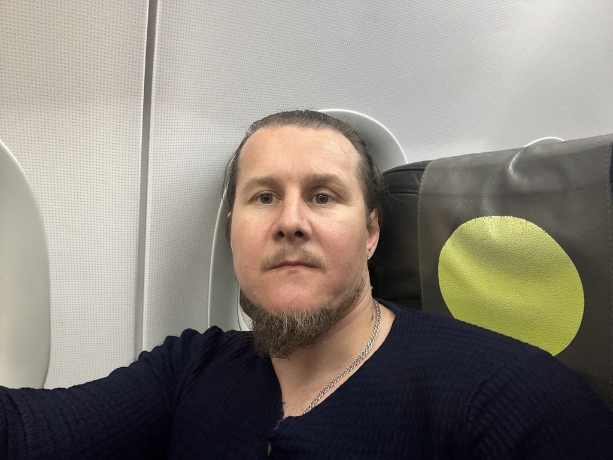

## Цель работы

Основной целью работы является знакомство с NETEM — инструментом для тестирования производительности приложений в виртуальной сети, а также получение навыков проведения интерактивного и воспроизводимого экспериментов по измерению задержки и её дрожания (jitter) в моделируемой сети в среде Mininet.

## Задание

1. Задайте простейшую топологию, состоящую из двух хостов и коммутатора с назначенной по умолчанию mininet сетью 10.0.0.0/8.
2. Проведите интерактивные эксперименты по добавлению/изменению задержки, джиттера, значения корреляции для джиттера и задержки, распределения времени задержки в эмулируемой глобальной сети.
3. Реализуйте воспроизводимый эксперимент по заданию значения задержки в эмулируемой глобальной сети. Постройте график.
4. Самостоятельно реализуйте воспроизводимые эксперименты по изменению задержки, джиттера, значения корреляции для джиттера и задержки, распределения времени задержки в эмулируемой глобальной сети. Постройте графики.

# Выполнение лабораторной работы

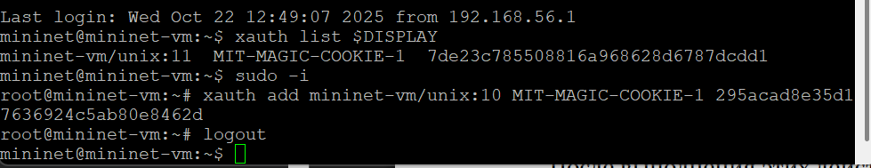

Исправление прав запуска X-соединения

## Выполнение лабораторной работы

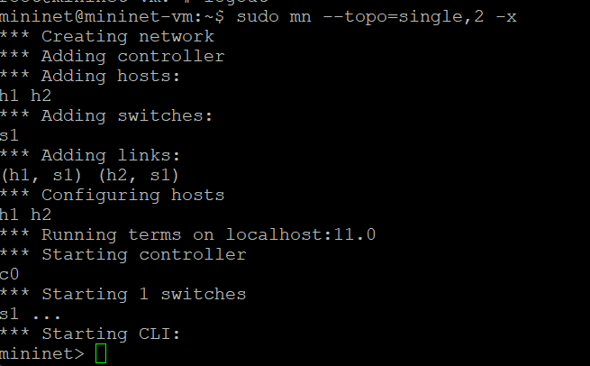

Простейшая топология

## Выполнение лабораторной работы

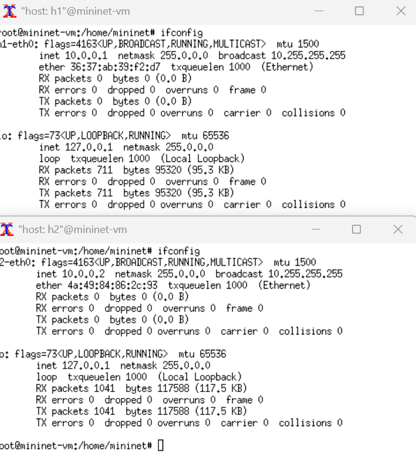

ifconfig на хостах h1 и h2

## Выполнение лабораторной работы

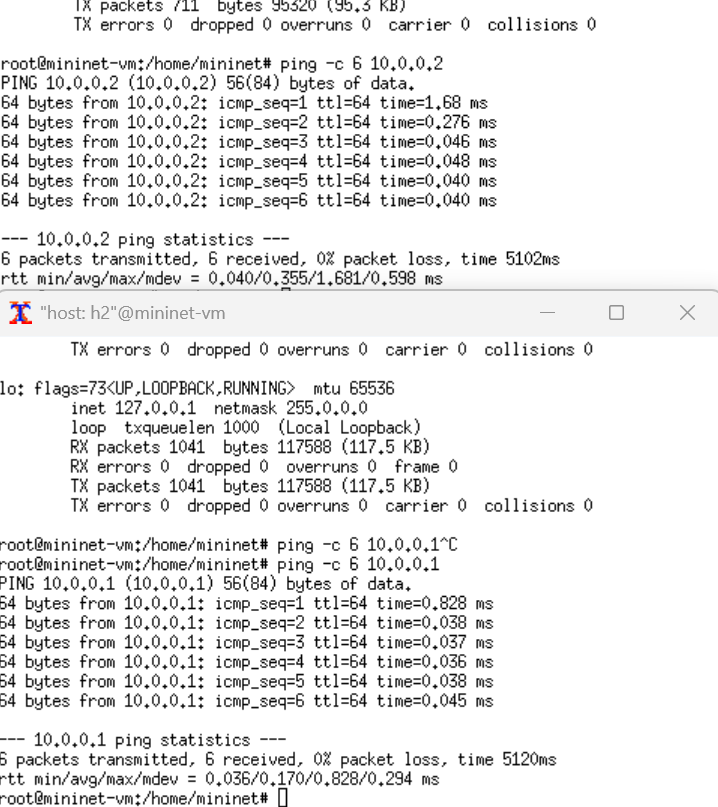

Проверка подключения между хостами

## Добавление/изменение задержки в эмулируемой глобальной сети

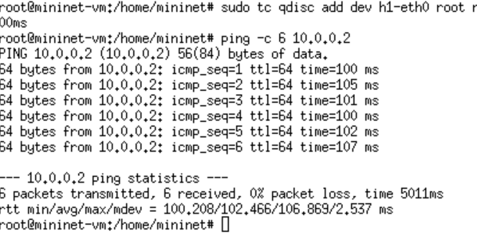

Добавление задержки в 100мс

## Добавление/изменение задержки в эмулируемой глобальной сети

[figure not shown]

Двунаправленная задержка соединения

## Изменение задержки в эмулируемой глобальной сети

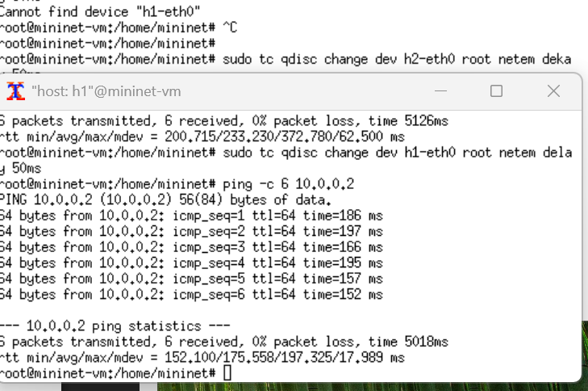

Изменение задержки на 50мс

## Восстановление исходных значений (удаление правил) задержки в эмулируемой глобальной сети

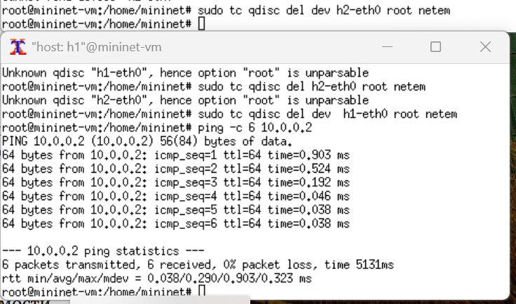

Восстановление исходных значений задержки

## Добавление значения дрожания задержки в интерфейс подключения к эмулируемой глобальной сети

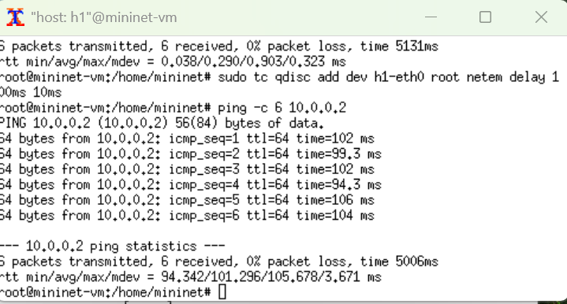

Добавление значения дрожания задержки в интерфейс подключения

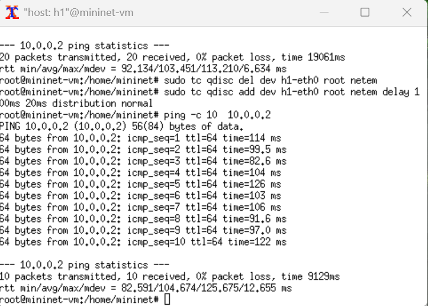

[figure not shown]

## Воспроизведение экспериментов. Добавление задержки для интерфейса, подключающегося к эмулируемой глобальной сети

```python
14 def emptyNet():
15
16 "Create an empty network and add nodes to it."
18 net = Mininet( controller=Controller,  waitConnected=True )
20 info( '*** Adding controller\n' )
21 net.addController( 'c0' )
23 info( '*** Adding hosts\n' )
24 h1 = net.addHost( 'h1', ip='10.0.0.1' )
25 h2 = net.addHost( 'h2', ip='10.0.0.2' )
```

## Воспроизведение экспериментов. Добавление задержки для интерфейса, подключающегося к эмулируемой глобальной сети

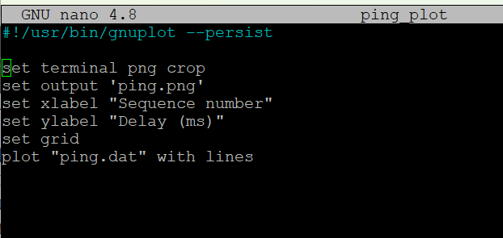

скрипт для визуализации ping_plot

## Воспроизведение экспериментов. Добавление задержки для интерфейса, подключающегося к эмулируемой глобальной сети

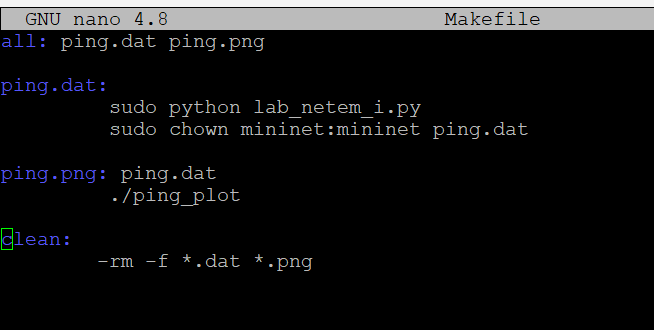

Makefile для управления процессом проведения эксперимента

## Воспроизведение экспериментов. Добавление задержки для интерфейса, подключающегося к эмулируемой глобальной сети

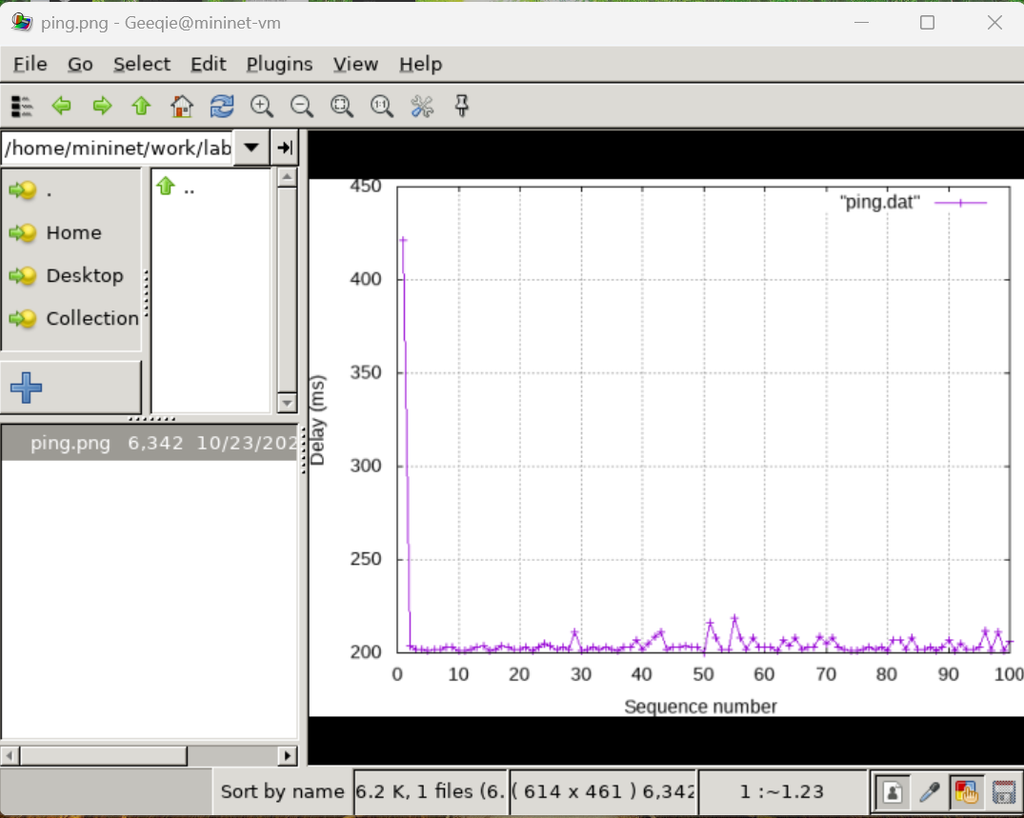

результате выполнения скриптов

## Воспроизведение экспериментов. Добавление задержки для интерфейса, подключающегося к эмулируемой глобальной сети

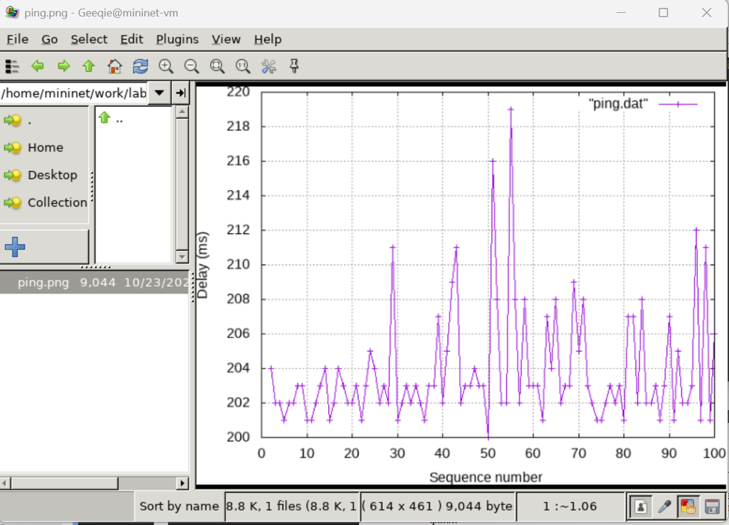

результате выполнения скриптова

## Воспроизведение экспериментов. Добавление задержки для интерфейса, подключающегося к эмулируемой глобальной сети

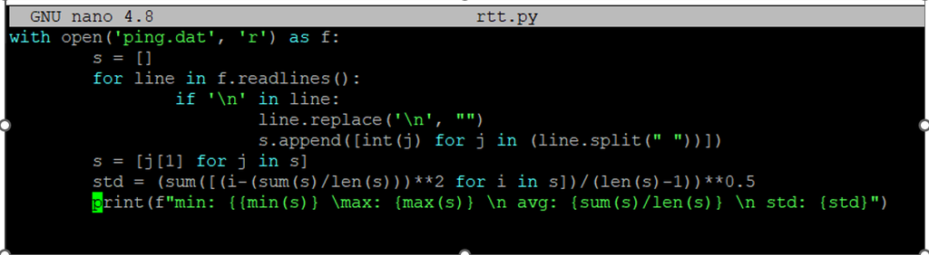

Cкрипт rtt.py

## Воспроизведение экспериментов. Добавление задержки для интерфейса, подключающегося к эмулируемой глобальной сети

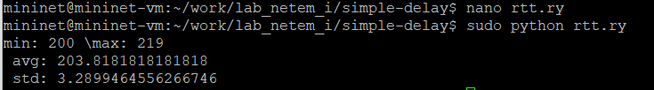

Результат работы скрипта rtt.py

## Выводы

В результате выполнения данной лабораторной работы я познакомился с NETEM – инструментом для тестирования производительности приложений в виртуальной сети, а также получил навыки проведения интерактивного и воспроизводимого экспериментов по измерению задержки и её дрожания (jitter) в моделируемой сети в среде Mininet.

## Список литературы

1. Mininet [Электронный ресурс]. Mininet Project Contributors. URL: http://mininet.org/ (дата обращения: 17.11.2024).